# Practical-machine-learning-project

Surjya Padhi

June 28, 2017

## Introduction

Using devices such as Jawbone Up, Nike FuelBand, and Fitbit it is now possible to collect a large amount of data about personal activity relatively inexpensively. These type of devices are part of the quantified self movement - a group of enthusiasts who take measurements about themselves regularly to improve their health, to find patterns in their behavior, or because they are tech geeks. One thing that people regularly do is quantify how much of a particular activity they do, but they rarely quantify how well they do it. In this project, our goal will be to use data from accelerometers on the belt, forearm, arm, and dumbell of 6 participants. They were asked to perform barbell lifts correctly and incorrectly in 5 different ways. The goal of this project is to predict the manner in which they did the exercise.

## Load the data

```r
#Load libraries
library("caret")
```

```r
#Download the data
if(!file.exists("pml-training.csv"))
  {download.file("https://d396qusza40orc.cloudfront.net/predmachlearn/pml-training.csv", destfile = "pml-training.csv")}

if(!file.exists("pml-testing.csv"))
{download.file("https://d396qusza40orc.cloudfront.net/predmachlearn/pml-testing.csv", destfile = "pml-testing.csv")}

#Read the training data and replace empty values by NA
training<- read.csv("pml-training.csv", sep=",", header=TRUE, na.strings = c("NA","",'#DIV/0!'))
testing<- read.csv("pml-testing.csv", sep=",", header=TRUE, na.strings = c("NA","",'#DIV/0!'))
dim(training)
```

```
## [1] 19622   160
```

```r
dim(testing)
```

```
## [1]  20 160
```

Our data consists of 19622 values of 160 variables.

## Clean the data

Now we remove columns with missing value.

```r
training <- training[,(colSums(is.na(training)) == 0)]
dim(training)
```

```
## [1] 19622    60
```

```r
testing <- testing[,(colSums(is.na(testing)) == 0)]
dim(testing)
```

```
## [1] 20 60
```

We reduced our data to 60 variables.

## Preprocess the data

```r
numericalsIdx <- which(lapply(training, class) %in% "numeric")

preprocessModel <-preProcess(training[,numericalsIdx],method=c('knnImpute', 'center', 'scale'))
pre_training <- predict(preprocessModel, training[,numericalsIdx])
pre_training$classe <- training$classe

pre_testing <-predict(preprocessModel,testing[,numericalsIdx])
```

## Removing the non zero variables

```r
nzv <- nearZeroVar(pre_training,saveMetrics=TRUE)
pre_training <- pre_training[,nzv$nzv==FALSE]

nzv <- nearZeroVar(pre_testing,saveMetrics=TRUE)
pre_testing <- pre_testing[,nzv$nzv==FALSE]
```

## Validation set

```r
set.seed(12031987)
idxTrain<- createDataPartition(pre_training$classe, p=3/4, list=FALSE)
training<- pre_training[idxTrain, ]
validation <- pre_training[-idxTrain, ]
dim(training) ; dim(validation)
```

```
## [1] 14718    28
```

```
## [1] 4904   28
```

## Train Model

```r
library(randomForest)
modFitrf <- train(classe ~., method="rf", data=training, trControl=trainControl(method='cv'), number=5, allowParallel=TRUE, importance=TRUE )
modFitrf
```

```
## Random Forest
##
## 14718 samples
##    27 predictor
##     5 classes: 'A', 'B', 'C', 'D', 'E'
##
## No pre-processing
## Resampling: Cross-Validated (10 fold)
## Summary of sample sizes: 13246, 13245, 13248, 13245, 13247, 13246, ...
## Resampling results across tuning parameters:
##
##   mtry  Accuracy   Kappa
##    2    0.9930692  0.9912329
##   14    0.9924572  0.9904587
##   27    0.9891272  0.9862463
##
## Accuracy was used to select the optimal model using  the largest value.
## The final value used for the model was mtry = 2.
```

## Interpretation

Let’s plot the importance of each individual variable

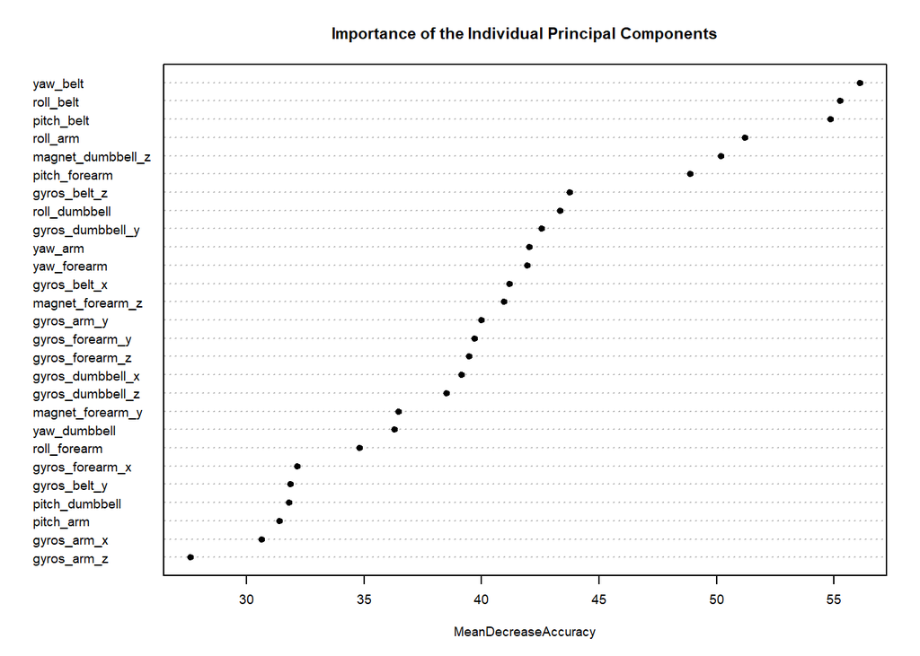

```r
varImpPlot(modFitrf$finalModel, sort = TRUE, type = 1, pch = 19, col = 1, cex = 0.6, main = "Importance of the Individual Principal Components")
```

## Cross Validation Testing and Out-of-Sample Error Estimate

# Accuracy and Estimated out of sample error

```r
predValidRF <- predict(modFitrf, validation)
confus <- confusionMatrix(validation$classe, predValidRF)
confus$table
```

```
##           Reference
## Prediction    A    B    C    D    E
##          A 1392    2    0    0    1
##          B    3  945    1    0    0
##          C    0    2  851    2    0
##          D    0    0    3  801    0
##          E    0    0    0    3  898
```

We can notice that there are very few variables out of this model.

```r
accur <- postResample(validation$classe, predValidRF)
modAccuracy <- accur[[1]]
modAccuracy
```

```
## [1] 0.9965334
```

```r
out_of_sample_error <- 1 - modAccuracy
out_of_sample_error
```

```
## [1] 0.003466558
```

The estimated accuracy of the model is 99.7% and the estimated out-of-sample error based on our fitted model applied to the cross validation dataset is 0.3%.

## Application of this model on the 20 test cases provided

```r
pred_final <- predict(modFitrf, pre_testing)
pred_final
```

```
##  [1] B A B A A E D B A A B C B A E E A B B B
## Levels: A B C D E
```